# Inkwell.ai — An AI-Powered Writing Marketplace Connecting Independent Writers and Magazine Publishers

### 6.1.5 Realisation

**Figure 6.8 – A premium article behind the paywall**

**Figure 6.9 – The plans: free and premium**

**Figure 6.10 – A magazine’s subscription and credits**

**Figure 6.11 – The marketplace, with preview and purchase prices**

**Figure 6.12 – A listing before preview**

**Figure 6.13 – Confirming a preview unlock: price and balance after**

**Figure 6.14 – The magazine’s library: unpublished and published**

**Figure 6.15 – Publishing a purchased article under the magazine’s masthead**

**Figure 6.16 – A licensed article naming both the writer and the magazine**

**Figure 6.17 – A magazine’s public profile and its published articles**

**Figure 6.18 – A writer’s earnings, itemised by preview and purchase**

**Figure 6.19 – A sold article, as its author sees it**

**Figure 6.20 – Administration: manual eligibility grant**

**Figure 6.21 – Administration: user management**

**Figure 6.22 – Administration: the report queue**

## 6.2 Sprint 6 — Tests, demonstration and deployment

### 6.2.1 Sprint goal and backlog

**Goal:** prove the business rules with tests, make the product demonstrable on a realistic corpus, and make it deployable with one command and an automated pipeline.

**Table 6.3 – Sprint 6 backlog**

| ID | User story | Priority | Points |
| --- | --- | --- | --- |
| US-52 | Apply migrations automatically before the application starts | Must | 5 |
| US-53 | Seed a believable corpus so that the product can be demonstrated cold | Must | 5 |
| US-54 | Lower the eligibility thresholds under a flag so that the gate can be crossed live | Must | 2 |
| US-55 | Serve the product at a public URL over TLS | Must | 8 |
|  | **4 stories** |  | **20** |

### 6.2.2 Test strategy

Figure 6.23 shows the strategy. The base is the **unit and service tests** of the backend, which run against a real PostgreSQL database rather than mocks, so that constraints, transactions and row locks are exercised for real. Above them, **integration tests** go through the API — authentication, publishing, purchasing — and verify the ledger afterwards. At the top, **end-to-end tests** drive a real browser over a seeded corpus. Two families protect the money: the **ledger invariant harness**, whose tests are mostly negative — a fixture builds a coherent purchase, corrupts one column and checks that the right invariant fires — and a **price sweep** that checks every price from 1 to 300 credits, both stages and both splits, reconciling exactly. The harness was validated by sabotage: removing a filter from the earnings query or a stage from the debit list fails exactly the tests that should fail, an exercise that found one coverage gap which was then closed.

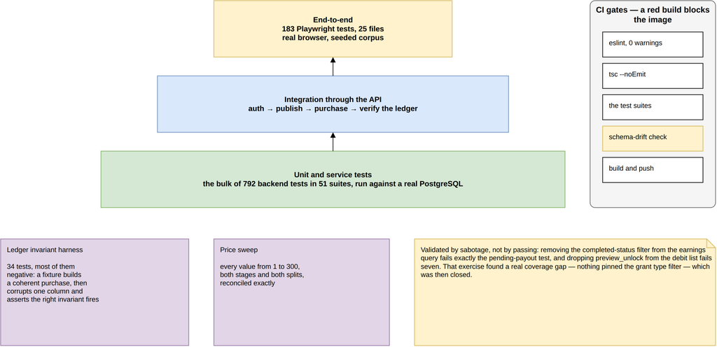

Figure 6.23 – Test strategy

**Table 6.4 – Test results**

| Suite | Scope | Result |
| --- | --- | --- |
| Backend (Jest) | 51 suites — services, controllers, ledger, purchases, documents, voice, AI pipeline | **792 tests, all passing** |
| Ledger invariant harness | balance and ledger invariants, seed ledger | 34 tests, included above |
| Price sweep | prices 1–300, both stages, both splits | included above |
| End-to-end (Playwright) | 25 spec files over the seeded corpus | 183 tests |
| Static gates | `tsc --noEmit` and `eslint --max-warnings=0`, both repositories | pass |

### 6.2.3 Demonstration corpus

A seed command builds a believable dataset in seconds and can rebuild it from scratch: its full preset creates **100 writers and 989 articles**, **50 magazines** (30 with a live subscription), **150 readers**, 110 marketplace listings with real purchases and ledger rows, and more than 15,000 likes, 2,700 reposts and 8,000 comments, with generated cover art and avatars uploaded to object storage. A fixed cast of named accounts makes every demonstration path reproducible, and a flag lowers the eligibility thresholds so that the gate can be crossed live during a demonstration. Every seeded date is relative to the seed’s clock and can be bounded below, so the corpus never predates the platform.

### 6.2.4 Deployment

The production stack is ready to run on a single server:

- **multi-stage images** for the API and worker (one image, two entry points) and for the Next.js server in standalone mode;
- a **production Compose file** in which only nginx is published, on ports 80 and 443, with TLS certificates from Let’s Encrypt renewed through certbot;
- a **one-shot migration service** that must succeed before the API and worker start;
- **health and readiness endpoints** checked by Compose and by the deployment workflow;
- the **continuous-delivery workflow** of Chapter 3, from the quality gates to the image registry and the server.

The domain `inkwell-ai.me` is registered. The remaining step — provisioning the server and pointing the domain at it — is listed with the perspectives.

## Conclusion

Release 3 delivered the marketplace end to end — subscriptions and credits, the eligibility gate, the exclusive two-stage purchase, the magazine’s own publication and the writer’s itemised earnings, all on a ledger whose invariants are tested after every operation — together with moderation, a test suite of 792 backend tests, a demonstration corpus and a production-ready deployment. The last release deepens the social layer and reworks the assistant.

# Chapter 7 — Release 4: social depth, the reworked assistant and documents

## Introduction

The last release deepens what the platform already did. Sprint 7 completes the social layer with comment likes, follower lists, blocking, saving and sharing. Sprint 8 reworks the assistant: it now decides on each request whether to answer or to write into the document, shows its real pipeline as it runs, and accepts and speaks voice; the feed card becomes interactive. Sprint 9 gives the writer a private library of reference documents that the assistant can draw on and cite by page.

## 7.1 Sprint 7 — Comment likes, lists, block, save and share

### 7.1.1 Sprint goal and backlog

**Goal:** readers like comments, browse and act on follower lists, block accounts, keep articles for later and share them outside the platform.

**Table 7.1 – Sprint 7 backlog**

| ID | User story | Priority | Points |
| --- | --- | --- | --- |
| US-57 | Save an article to come back to it later, without anyone else seeing what I keep | Must | 5 |
| US-58 | Pass an article on to people outside the platform so that they can read it without signing up | Should | 3 |
| US-56 | Block an account so that I stop seeing someone without having to explain myself | Must | 5 |
|  | **3 stories** |  | **13** |

### 7.1.2 Analysis

Figure 7.1 gives the use cases of Sprint 7. Sharing and the follower lists need no account; following from a list extends viewing it. Liking a comment and saving an article include notifying the recipient. A block hides the two accounts from each other — profiles, articles and comments — and the only place to lift it is the blocker’s settings. Saves are private: the author is notified, but nobody else can see what a reader keeps.

[figure not shown]

Figure 7.1 – Use case diagram, Sprint 7

### 7.1.3 Design

Figure 7.2 shows the three new tables — `CommentLike`, `Block` and `Save` — and the two notification types they emit. Each carries a unique constraint on its pair, so a repeated request is a no-op, and a notification is emitted only when a row was actually inserted; a check constraint forbids blocking oneself. A block row is directional, but every read treats it both ways. Comment likes are kept in their own table rather than among article likes, so that by construction they can never count towards a writer’s eligibility.

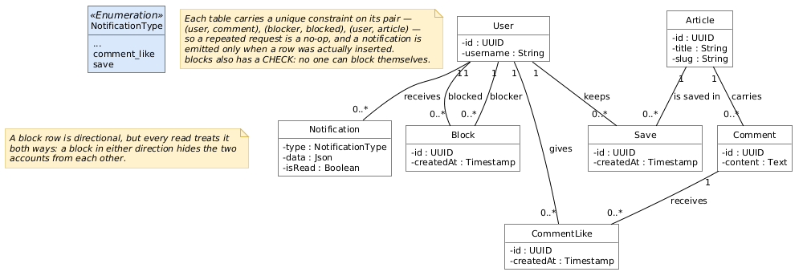

Figure 7.2 – Class diagram, Sprint 7

### 7.1.4 Realisation

**Figure 7.3 – The Saved shelf**

**Figure 7.4 – Blocked accounts, in settings**

**Figure 7.5 – The following feed**

**Figure 7.6 – A follower list, searched**

## 7.2 Sprint 8 — Live cards, the assistant that writes, and voice

### 7.2.1 Sprint goal and backlog

**Goal:** readers react, repost and comment from the feed card, see recent comments and preview any byline; the assistant decides whether to answer or to write into the document, writes into a protected range the writer keeps or discards, shows its steps as they run, sits in a panel docked beside the editor, accepts dictated prompts and reads its replies aloud.

**Table 7.2 – Sprint 8 backlog**

| ID | User story | Priority | Points |
| --- | --- | --- | --- |
| US-59 | React to an article from the feed so that I can engage without losing my place | Must | 5 |
| US-60 | See what an account has reposted so that I can judge what they rate | Should | 3 |
| US-61 | Reply in the moment from the feed so that a fresh conversation is easy to join | Could | 3 |
| US-62 | Keep reading as I scroll so that a list does not end at an arbitrary point I have to click past | Must | 5 |
| US-65 | See who a writer or magazine is from where their name appears so that I can decide to follow without leaving the feed | Should | 3 |
| US-66 | Tell the assistant what to write and watch it appear in my draft, then keep or discard it, so that generation happens where I write rather than in a chat I copy from | Must | 8 |
| US-67 | See what the assistant is doing while it works — and minimize it without losing sight of that — so that a slow step is not a frozen screen | Should | 3 |
| US-68 | Say my request instead of typing it so that I can brief the assistant while my hands are busy or my thoughts are faster than my typing | Should | 5 |
| US-69 | Hear the assistant’s recap read out so that I can keep my eyes on the draft — and mute it when I would rather not | Could | 3 |
|  | **9 stories** |  | **38** |

### 7.2.2 Analysis

Figure 7.7 gives the use cases of Sprint 8. Briefing the assistant specialises into receiving an answer in the panel and having text written into the document, and includes following the live pipeline steps and consuming the allowance; keeping or discarding the written text includes the write. Dictating extends the brief and is billed; hearing the reply extends the answer. The choice between answering and writing is the assistant’s, made per message; it supersedes the manual “insert the answer into the document” of Sprint 2 (FR-30, superseded by FR-78).

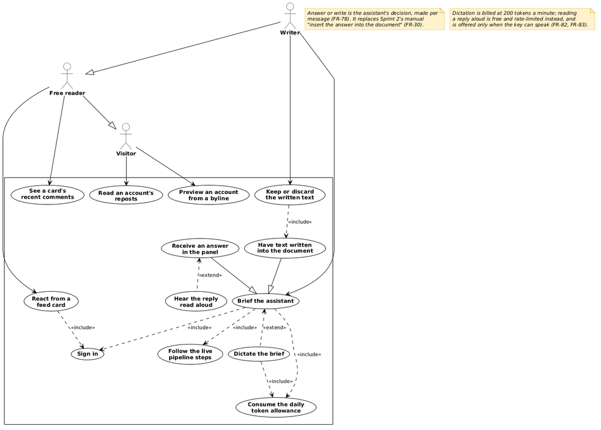

Figure 7.7 – Use case diagram, Sprint 8

### 7.2.3 Design

**Sequence diagram — one assistant turn.** Figure 7.8 shows a turn. The request carries the conversation, the article and any selection. The system reads the draft, the writer’s voice profile and — when documents are attached — passages from them, reporting each stage to the panel as it completes. A single routing call to the model then either answers in the panel, streamed as Markdown, or calls the `write_to_article` tool with a placement (at the cursor or over the selection) and a one-line brief; the write is described in Figure 7.9, after which the model adds a one-line recap. The tokens of both calls are settled once, at the end; a stopped turn still bills an estimate of what was produced. The response is a typed stream: status parts for each stage, text parts for the answer, and article parts for the write.

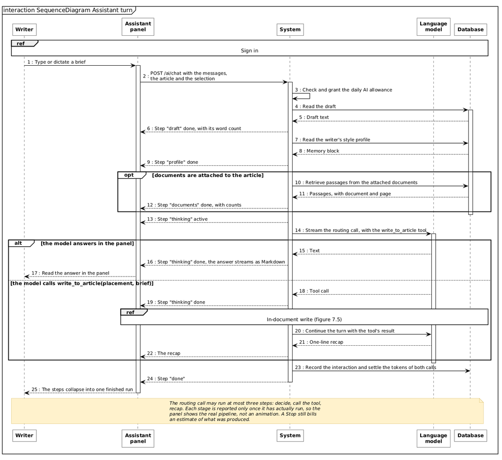

Figure 7.8 – Sequence diagram: one assistant turn

**Sequence diagram — writing into the document.** Figure 7.9 shows the write. The system retrieves passages from the writer’s other published articles and streams the article text from a second model call. The panel opens a range in the editor at a block boundary — after the block holding the cursor, or over the selected blocks — tints it and refuses the writer’s own edits inside it; each Markdown block is inserted as soon as it is complete, outside the undo history. When the stream ends, the writer keeps the text, which becomes one undo step, or discards it, which restores exactly what was there. Opening the range at a block boundary is what makes that restoration exact: every node the writer owns stays untouched.

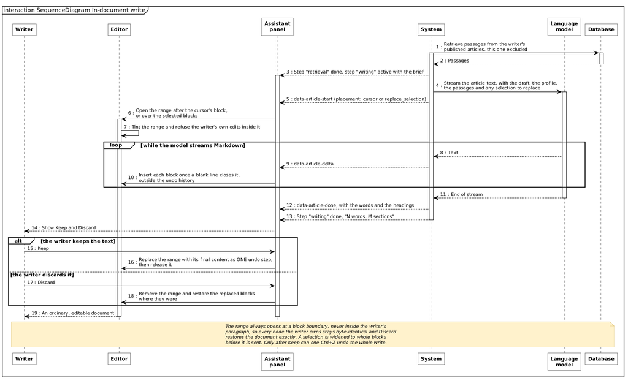

Figure 7.9 – Sequence diagram: writing into the document

**Sequence diagram — voice.** Figure 7.10 shows the voice round trip. A recording of at most five minutes is sent with its length; the system checks the allowance, the format and the size, transcribes it with Whisper, settles the duration — the provider’s when it reports one, otherwise the larger of the client’s figure and a floor derived from the file size — and bills 200 tokens per started minute. The transcript lands in the composer, editable. Reading a reply aloud is free to the writer and limited per account instead, to 20 replies a minute and 300 a day; the control exists only when speech synthesis is available, and the mute choice persists in the browser.

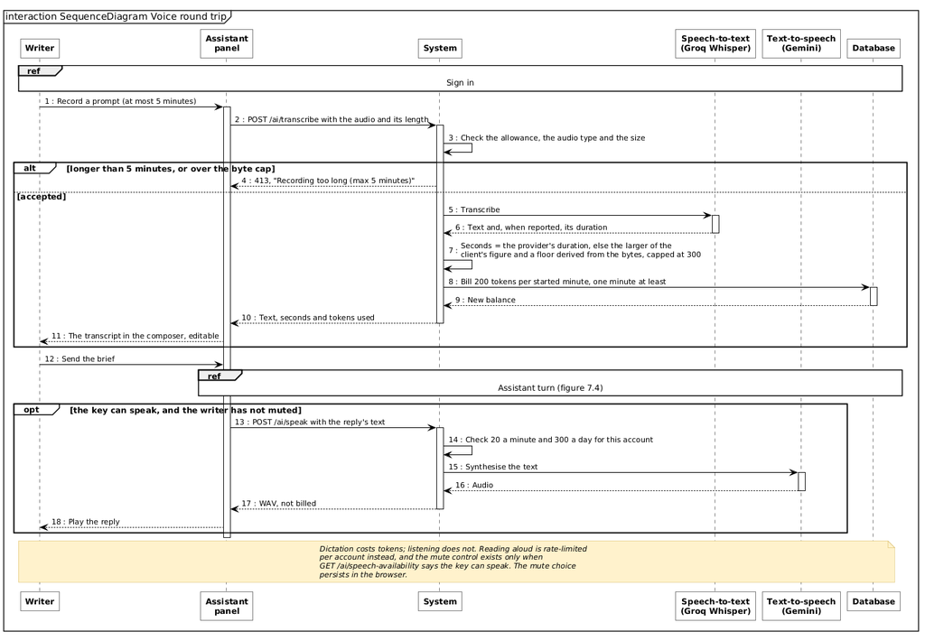

Figure 7.10 – Sequence diagram: the voice round trip

### 7.2.4 Realisation

**Figure 7.11 – The Reposted tab of a profile**

**Figure 7.12 – A write awaiting Keep or Discard**

**Figure 7.13 – The live step on the collapsed panel**

**Figure 7.14 – Recording a prompt**

## 7.3 Sprint 9 — Document library and citations

### 7.3.1 Sprint goal and backlog

**Goal:** a writer uploads reference documents into a private library, attaches them to an article, and the assistant draws on them for answers and writes, citing each passage by document and page.

**Table 7.3 – Sprint 9 backlog**

| ID | User story | Priority | Points |
| --- | --- | --- | --- |
| US-70 | Upload the documents I am working from so that the assistant can use their facts without my retyping them | Must | 8 |
| US-71 | Choose which documents apply to an article so that a piece on tides is not fed my notes on fermentation | Must | 3 |
| US-72 | See which document and page a claim came from so that I can check it before it goes out under my name | Should | 5 |
|  | **3 stories** |  | **16** |

### 7.3.2 Analysis

Figure 7.15 gives the use cases of Sprint 9. Managing the library specialises into uploading, retrying a failed document and deleting; uploading and retrying include extracting, chunking and embedding the text. Attaching documents to an article is extended by detaching one. Asking the assistant is extended by citing passages as *[Title, p. N]*, itself extended by opening a cited passage at its page. Documents are PDF, DOCX, TXT or Markdown files under 10 MB and 200 pages, at most 20 per writer. A document is the writer’s alone: it never feeds the voice profile, portfolio insights or search, and no other account can read, attach or discover it.

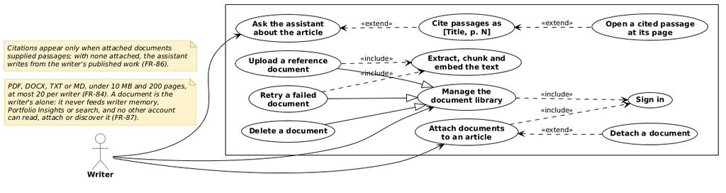

Figure 7.15 – Use case diagram, Sprint 9

### 7.3.3 Design

**Class diagram.** Figure 7.16 shows the library: a `Document` with its status, page and chunk counts and a readable error; its `DocumentChunk`s, each keeping the page it came from, which is what a citation points to; and the `ArticleDocument` attachments. The status moves from pending to extracting to ready, or to failed with a reason the writer can act on; the only backward move is a retry.

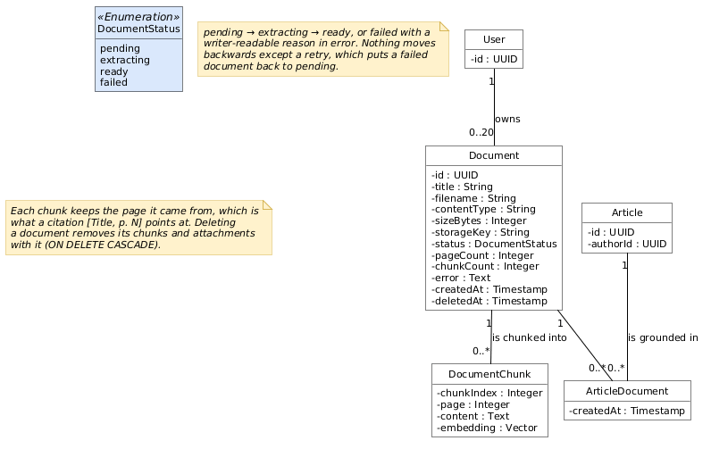

Figure 7.16 – Class diagram, Sprint 9

**Sequence diagram — ingestion.** Figure 7.17 shows a document’s path, the companion of the publishing pipeline of Chapter 5. The browser asks for a presigned URL and uploads the file straight to a private bucket — the file never passes through the API. The registration checks that the object exists and is under 10 MB, counts the writer’s documents under a per-writer lock and queues ingestion. The worker extracts the text page by page, refuses a document over 200 pages or without a text layer with a readable reason, then chunks it, embeds the chunks and marks it ready in one transaction. The file is served back only to its owner, through the API, as a short-lived URL.

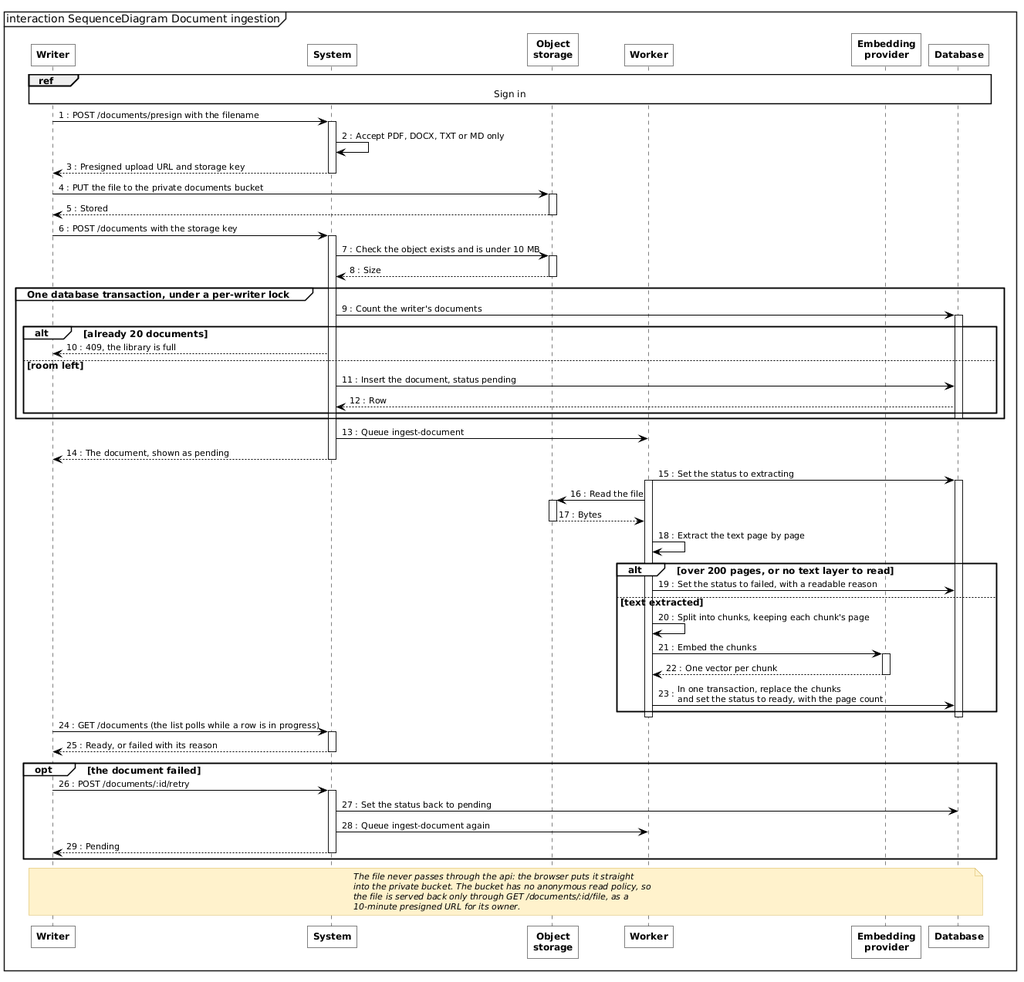

Figure 7.17 – Sequence diagram: document upload and ingestion

### 7.3.4 Realisation

**Figure 7.18 – The document library, one document refused with its reason**

**Figure 7.19 – Attaching a document from the Sources tab**

**Figure 7.20 – A reply citing its source as [Title, p. N]**

## Conclusion

Release 4 completed the social layer, turned the assistant from a chat beside the editor into a collaborator that writes into the document under the writer’s control, added voice in both directions, and gave the writer a private library of sources the assistant can cite to the page.

# General conclusion and perspectives

This project set out to connect two groups the existing platforms leave apart: independent writers, who lack an assistant that writes in their own voice and a direct way to be paid for quality, and magazines, which lack objective evidence to judge a writer before buying. Inkwell.ai answers both with one platform.

Over nine two-week sprints in four releases, the project delivered:

- a **writing environment** — a rich-text editor with automatic saving and images, and an AI assistant grounded in the writer’s own published work through retrieval-augmented generation, which decides per request whether to answer or to write into the document, writes into a protected range the writer keeps or discards, shows its real pipeline as it runs, accepts dictated prompts, reads its replies aloud, and cites reference documents to the page;
- an **analytics pipeline** — reading events captured in the browser, aggregated incrementally into per-article and per-writer metrics, presented to writers as dashboards and to magazines as an evaluation report completed by AI portfolio insights;
- a **marketplace** — an eligibility gate, magazine subscriptions with monthly credits, a two-stage exclusive purchase and the magazine’s own publication, with every credit movement written to a ledger inside one transaction and three balance invariants asserted after every money-moving test;
- a **social layer** — likes, threaded comments, comment likes, reposts, follows, saves, blocks, sharing and live notifications — and the **moderation** console;
- the **engineering around it** — a containerised stack started by one command, a continuous-integration pipeline with strict typing, zero lint warnings and a schema-drift check, 792 backend tests and 183 end-to-end tests, a demonstration corpus, and a production-ready deployment.

Beyond the product, the project was an exercise in engineering discipline: requirements stated per actor with stable identifiers, non-functional requirements tied to the mechanism that provides them, business rules proven by tests — including tests designed to fail when the code is sabotaged — and design documents and diagrams kept as versioned text beside the code.

## Limitations

Some points remain open and are stated as such:

- **Live hosting.** The production stack, its TLS configuration and its delivery pipeline are ready and the domain is registered, but the server has not yet been provisioned.
- **Refresh-token revocation.** Refresh tokens are stateless; their 7-day lifetime is the bound on their validity, and a password change or a ban does not revoke one already issued.
- **Pagination.** Lists are paginated by offset; a cursor-based scheme would stay stable when new rows are inserted while a reader scrolls.
- **Accessibility and performance audit.** A Lighthouse score above 90 and the absence of critical accessibility violations on article pages (NFR-37) remain to be measured.
- **Readiness.** The readiness endpoint checks PostgreSQL but not Redis.

## Perspectives

- **Go live** on a provisioned server, then measure real traffic against the performance requirements.
- **Real payments** in place of the simulated ones, with the ledger already designed to record them.
- **Revocable sessions**, by storing refresh tokens server-side.
- **Richer AI collaboration**: dictating whole articles, writer-specific style learning beyond the current voice profile, and feedback on weak sections.
- **Wider audience**: multilingual publishing and a native mobile application on the existing 375 px designs.
- **Deeper analytics**: geographic and device distribution collected with the reader’s consent, and topic-relevance ordering when magazines browse writers.

# References